# Simulation Results

# Simulation setup: a 15 fold scenario

- S1: D = 0.05 ; sigma = 200 m ; L0 = 2
- S2: D = 0.0033 ; sigma = 3000 m ; L0 = 0.133
- reps = 100

# Grids with 800 m spacing

### Data summary

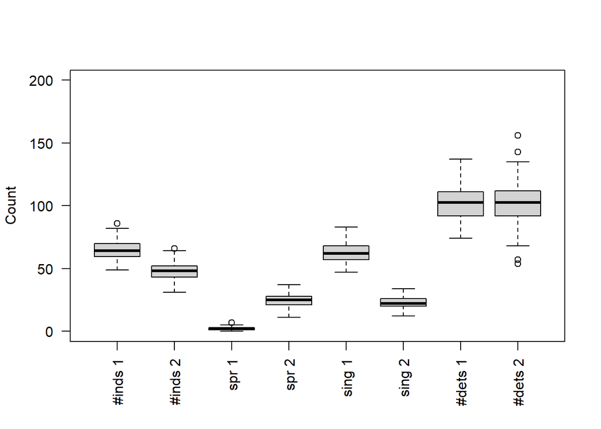

### Simulation Results

Sim Results from 800 m Grids

| Strata | D RB | D RSE | L0 RB | L0 RSE | Sigma RB | Sigma RSE | Reps |
| --- | --- | --- | --- | --- | --- | --- | --- |
| S1 | 10.4 | 0.273 | 2.8 | 0.191 | -2.7 | 0.116 | 98 |
| S2 | 6.6 | 0.503 | 4.2 | 0.192 | 8.9 | 0.333 | 85 |

# GA4 Designs (min(n,r))

## Data summaries

**Using S1 values:**

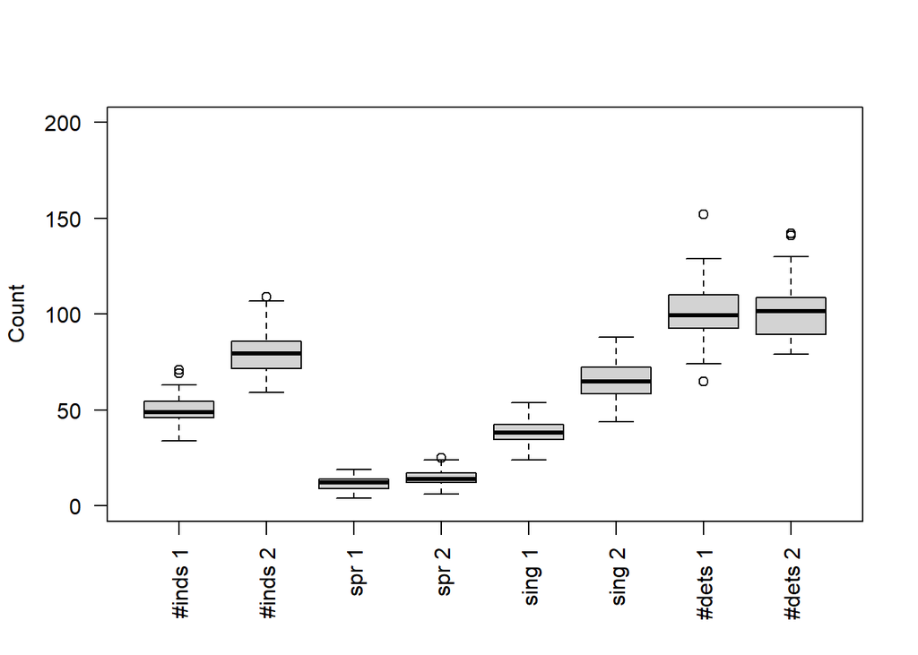

**Using S2 values:**

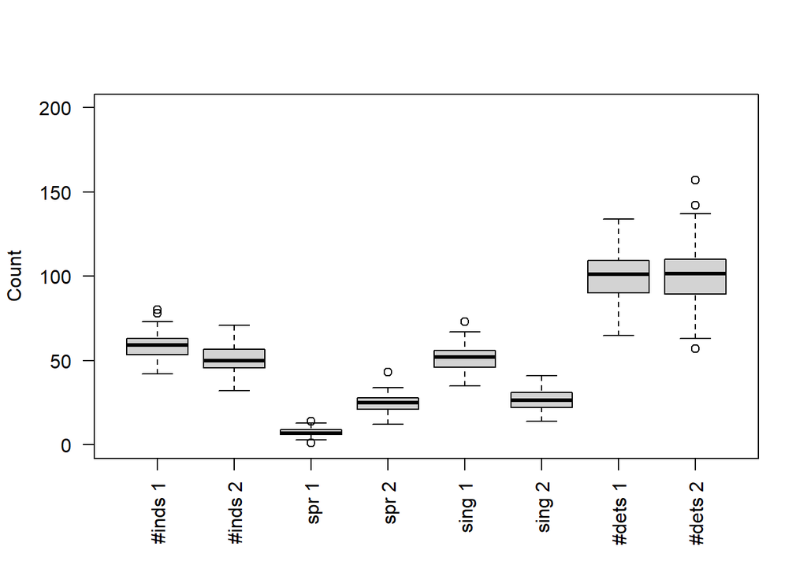

**Using Avg values:**

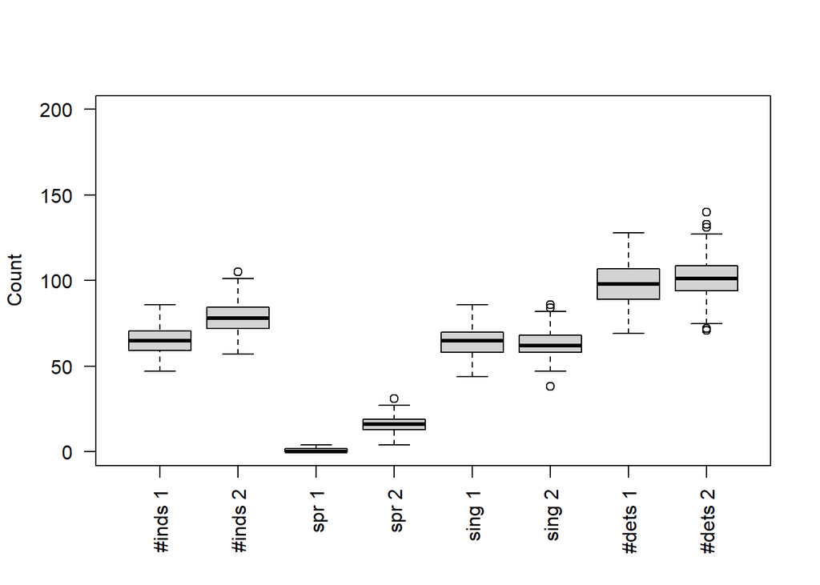

**Using Both values:**

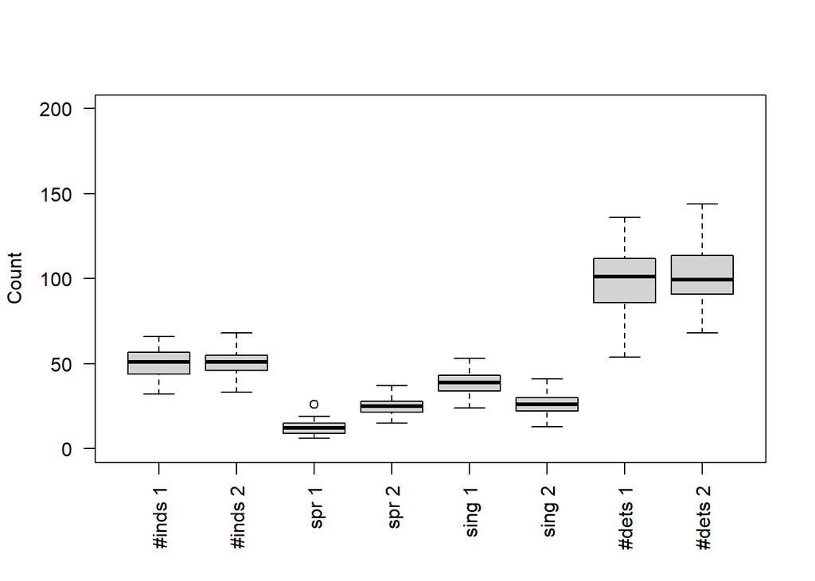

**Using Both (max-min) values:**

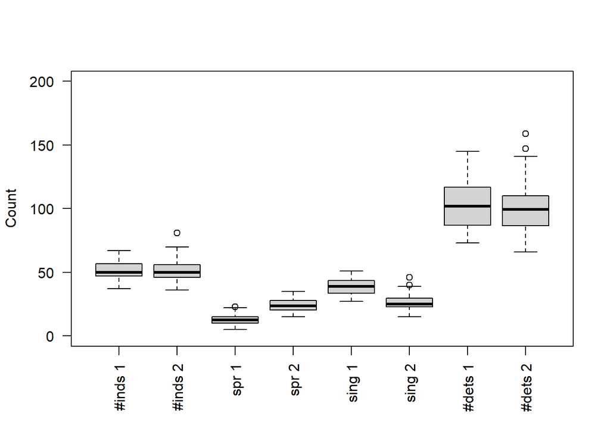

## Simulation Results

Sim Results from GA4 designs

| Values | Strata | D RB | D RSE | L0 RB | L0 RSE | Sigma RB | Sigma RSE | Reps |
| --- | --- | --- | --- | --- | --- | --- | --- | --- |
| S1 | S1 | 0.0 | 0.274 | 0.4 | 0.174 | 3.0 | 0.156 | 100 |
|  | S2 | 16.4 | 0.336 | 0.1 | 0.249 | -2.5 | 0.160 | 100 |
| S2 | S1 | 6.0 | 0.217 | -1.7 | 0.206 | -0.2 | 0.100 | 100 |
|  | S2 | 11.2 | 0.337 | 1.2 | 0.229 | 1.2 | 0.290 | 96 |
| Avg | S1 | 40.2 | 0.663 | -5.4 | 0.207 | -1.7 | 0.272 | 90 |
|  | S2 | 6.6 | 0.264 | 4.1 | 0.262 | -1.2 | 0.132 | 100 |
| Both | S1 | 5.1 | 0.219 | -1.3 | 0.217 | 0.0 | 0.134 | 100 |
|  | S2 | 7.6 | 0.347 | 1.8 | 0.195 | 1.6 | 0.214 | 98 |
| Both (Max) | S1 | 8.5 | 0.222 | 1.8 | 0.194 | -1.8 | 0.194 | 100 |
|  | S2 | 14.3 | 0.396 | 1.4 | 0.214 | -0.4 | 0.214 | 97 |

Realisations from the proposed designs:

**Using S1 values:**

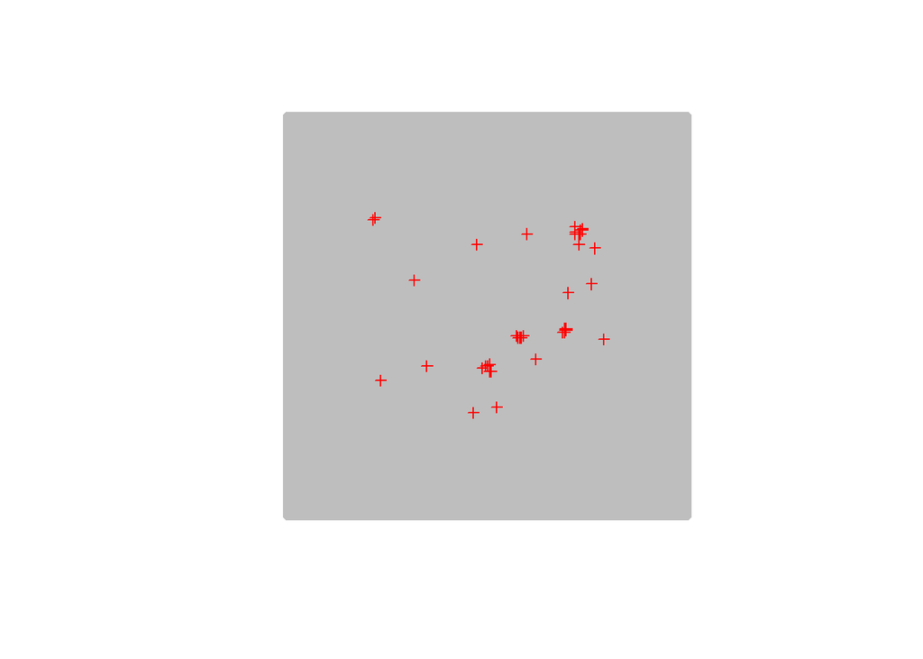

**Using S2 values:**

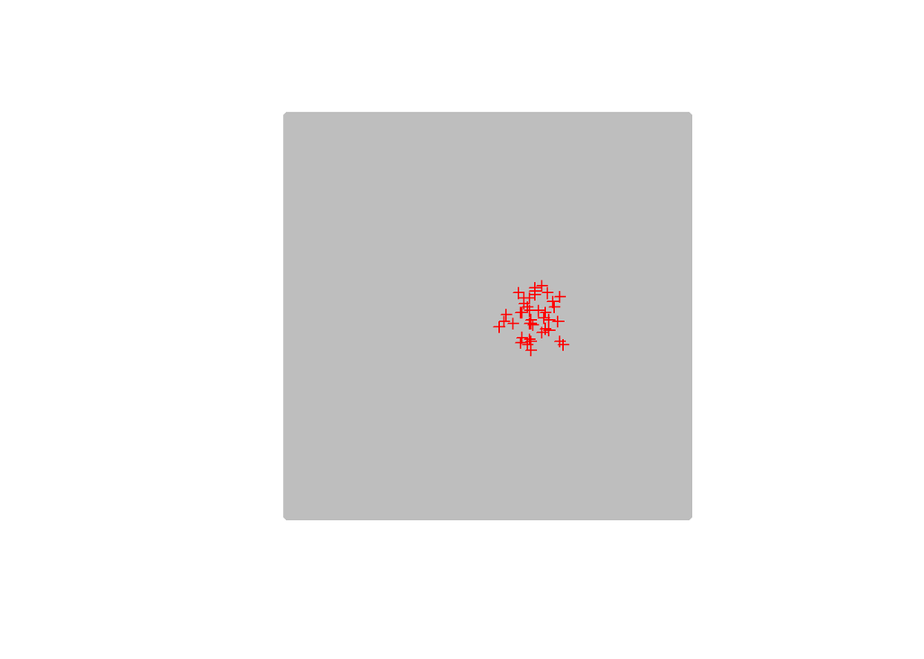

**Using Avg values:**

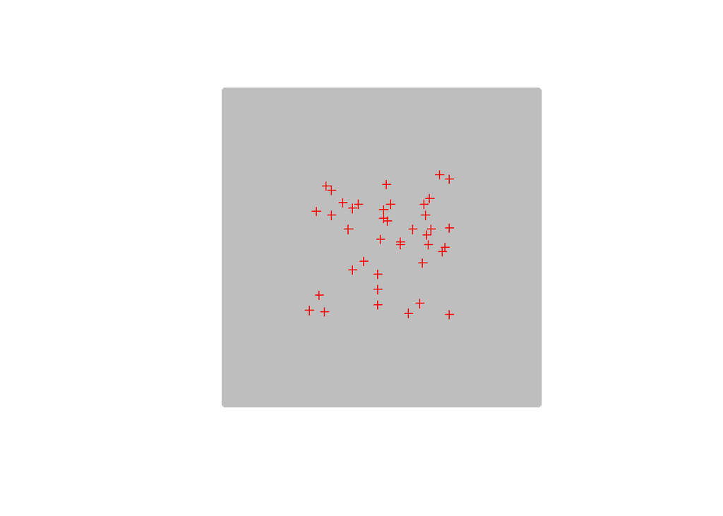

**Using Both values:**

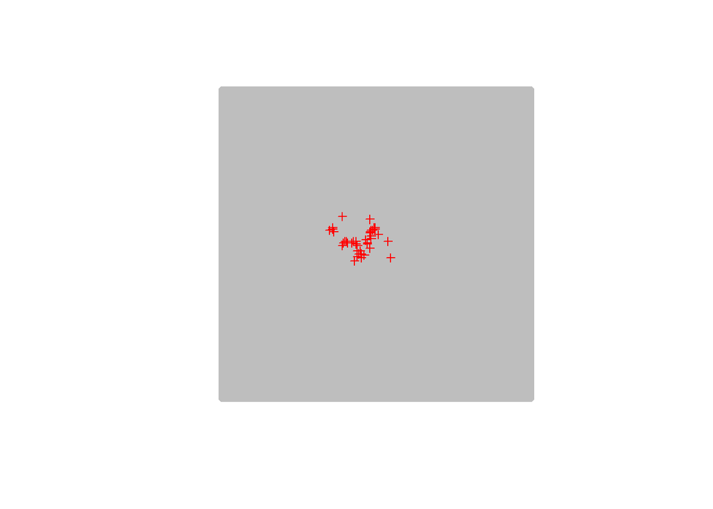

**Using Both (max-min) values:**

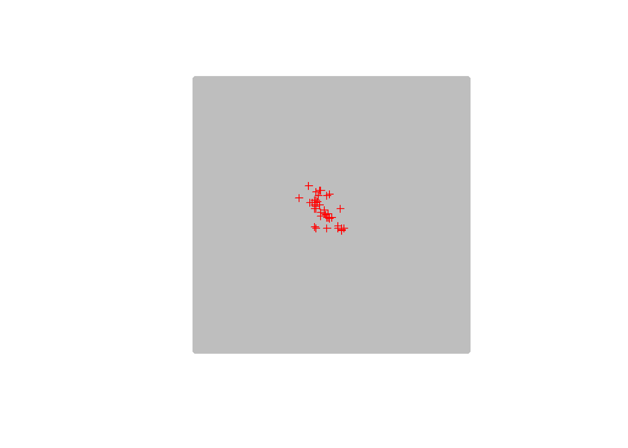

Note warning messages:

- S1 (2)
- S2 (2)
- Avg (9)
- Both / BothMax (0)

# GA5 Designs (E(n2))

## Data summaries

**Using S1 values:**

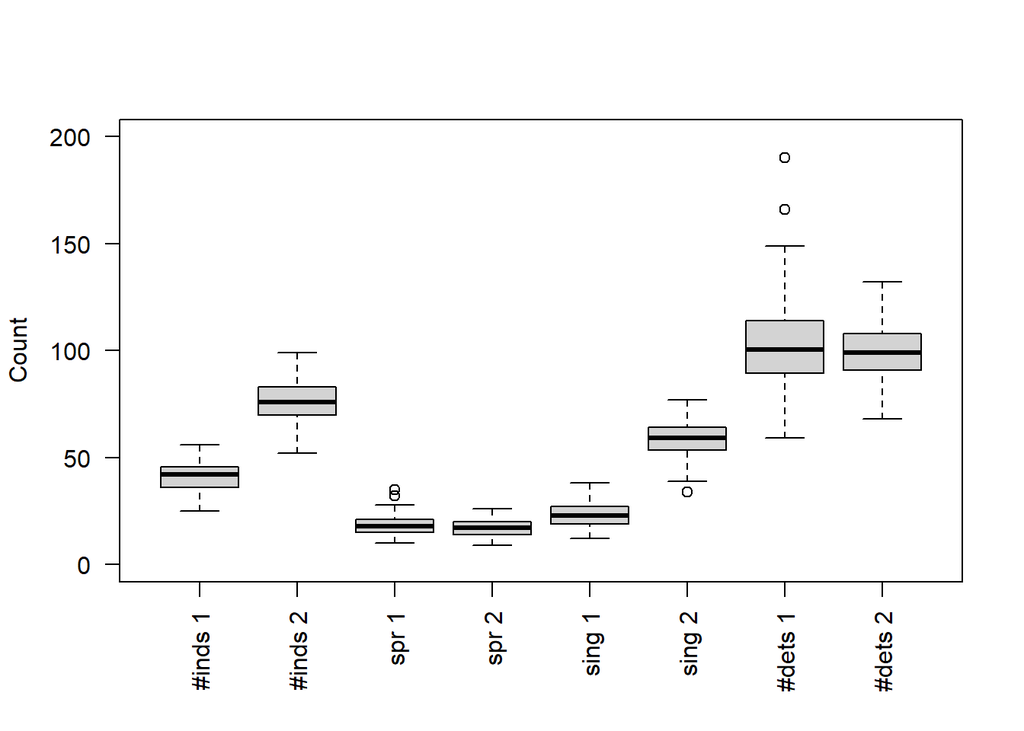

**Using S2 values:**

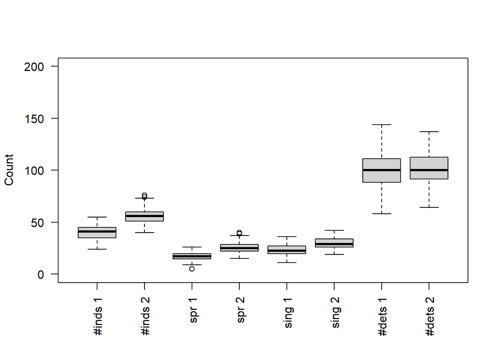

**Using Avg values:**

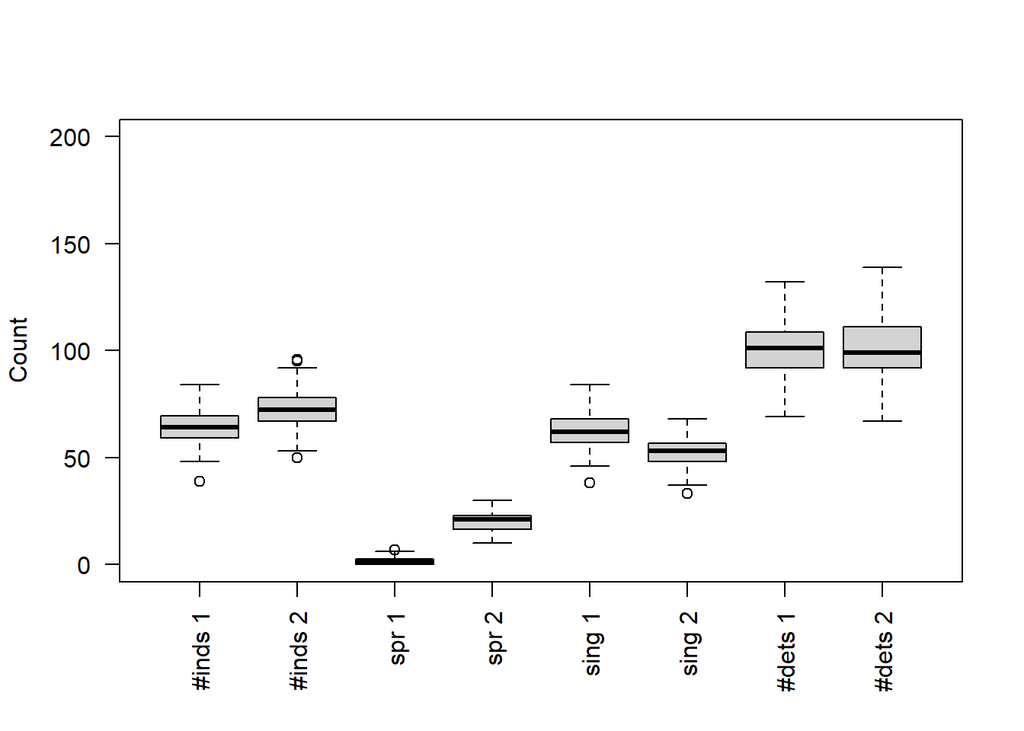

**Using Both values:**

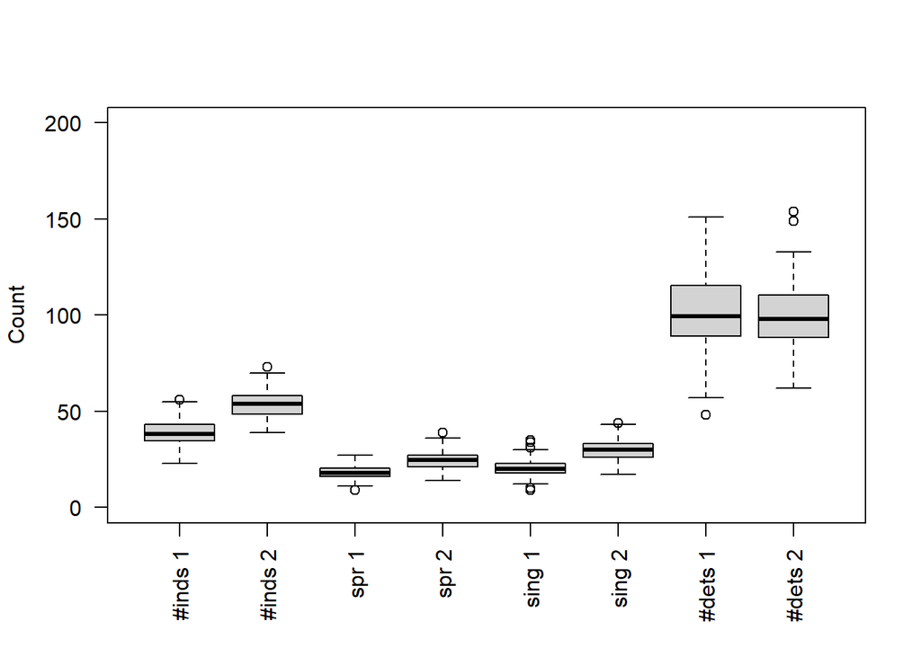

**Using Both (max-min) values:**

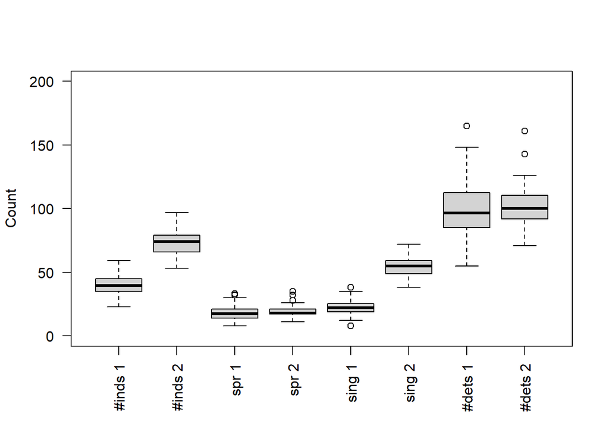

## Simulation Results

Sim Results from GA5 designs

| Values | Strata | D RB | D RSE | L0 RB | L0 RSE | Sigma RB | Sigma RSE | Reps |
| --- | --- | --- | --- | --- | --- | --- | --- | --- |
| S1 | S1 | 7.7 | 0.299 | 2.6 | 0.160 | -1.0 | 0.173 | 100 |
|  | S2 | 3.8 | 0.266 | 5.2 | 0.215 | -1.0 | 0.155 | 100 |
| S2 | S1 | 1.0 | 0.167 | -1.3 | 0.200 | 0.8 | 0.083 | 100 |
|  | S2 | 4.3 | 0.300 | -3.7 | 0.197 | 3.8 | 0.163 | 100 |
| Avg | S1 | 57.3 | 0.624 | 2.7 | 0.176 | -11.3 | 0.266 | 91 |
|  | S2 | 1.6 | 0.203 | -2.6 | 0.280 | 4.4 | 0.154 | 100 |
| Both | S1 | 2.2 | 0.234 | 5.6 | 0.178 | -1.4 | 0.116 | 100 |
|  | S2 | 3.5 | 0.306 | 0.8 | 0.205 | 1.6 | 0.188 | 100 |
| Both (Max) | S1 | 4.6 | 0.238 | -0.6 | 0.225 | -0.4 | 0.225 | 100 |
|  | S2 | 4.6 | 0.340 | 3.2 | 0.218 | 0.7 | 0.218 | 100 |

Realisations from the proposed designs:

**Using S1 values:**

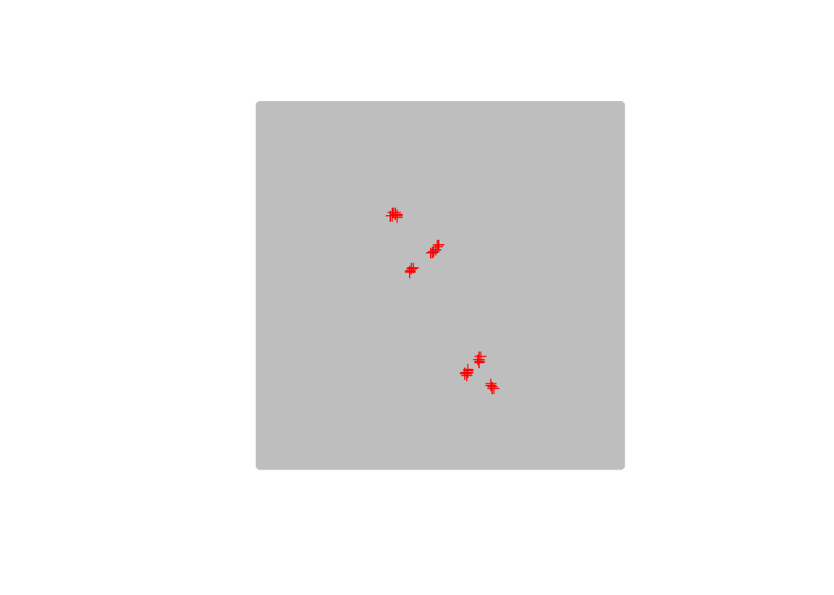

**Using S2 values:**

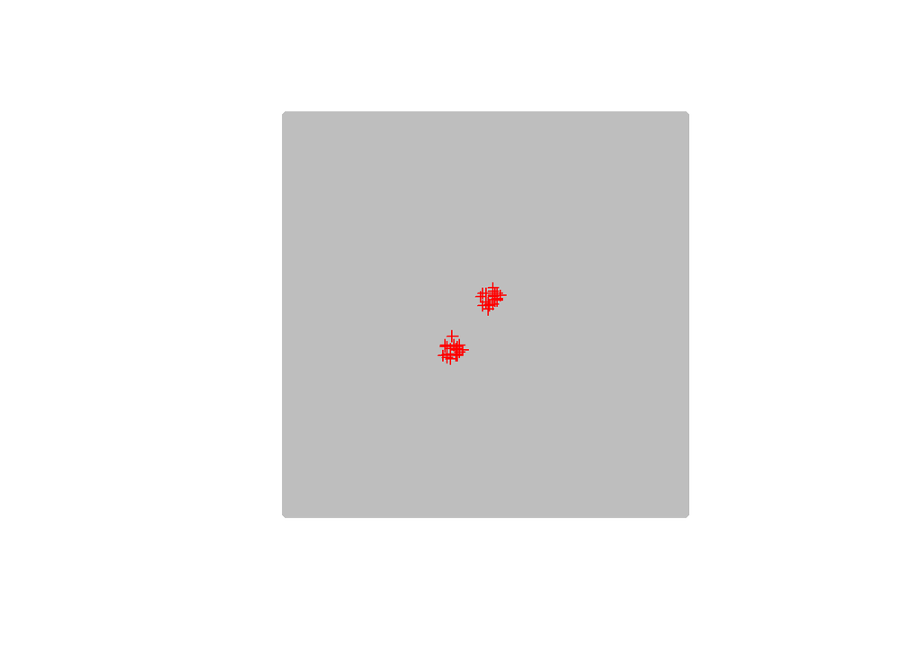

**Using Avg values:**

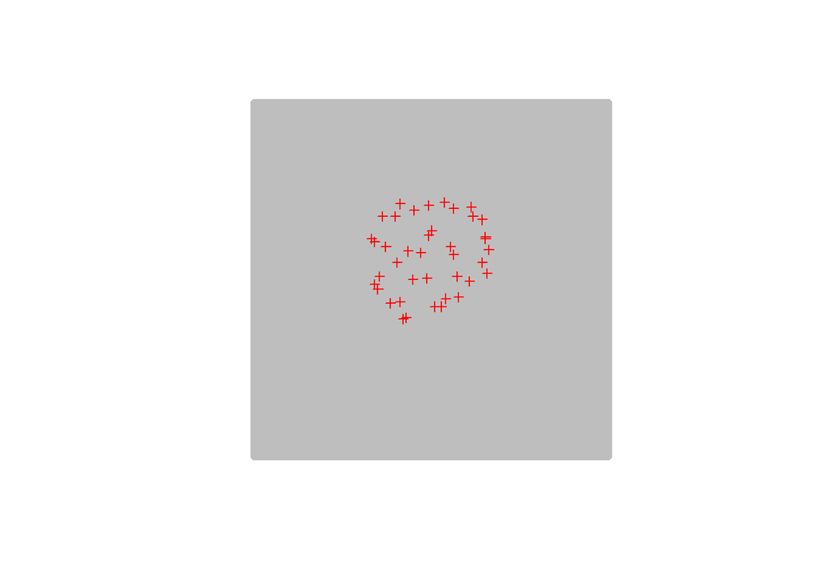

**Using Both values:**

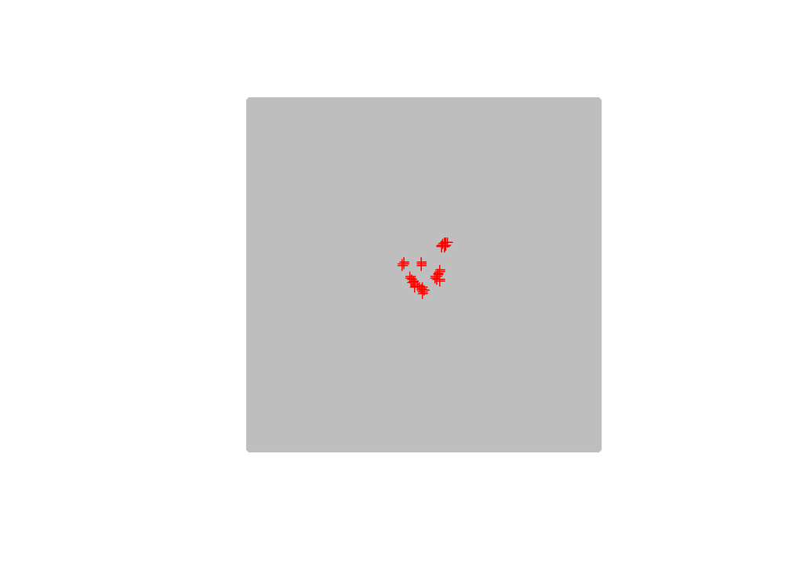

**Using Both (max-min) values:**

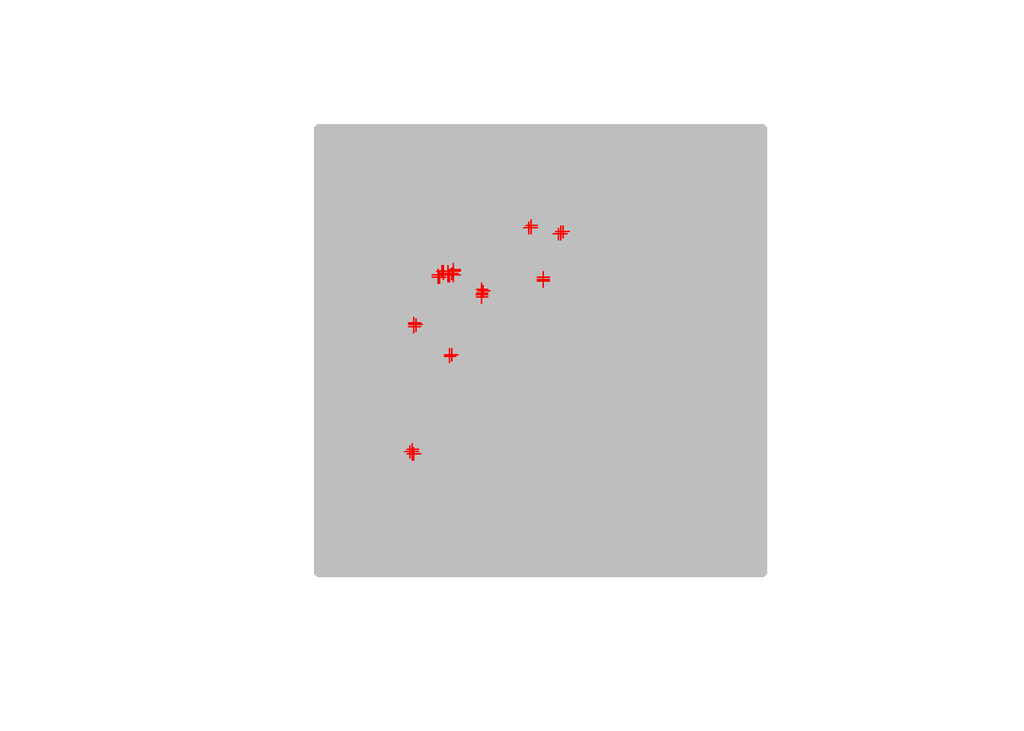

Comments:

- The behaviour of the GA4 algorithm seems to spread traps much further when using S1 or avg values. The other settings produce a fairly dense array with traps tending to be quite close together
- The behaviour of the GA5 algorithm consistently produces clusters of traps, except when using average values. Using S2 values produces two large clusters, and using both with max-min tends to produce clusters that are more spread out compared to without max-min
- Using avg values leads to high bias and relatively high variance in strata 1 for both genetic algorithms
- Not sure why there is some positive bias for strata 2 when using the GA4 algorithm with S2 values, similarly not sure why a handful of reps gave problems for estimates for S2. The data summary shows more spatial recaps and less singletons for S2 (wqith slightly lower n).